# Analysis of Loan Data from Prosper by James R. Small

> Prosper Marketplace is a peer-to-peer lender which facilitates individuals loaning and/or borrowing money from each other. This data set from March 11, 2014 provides a view into some of these loans. It consists of dozens of measures of individuals’ credit worthiness as well as metrics on these loans.

The raw data set has a few issues and some extraneous fields that aren’t of use in this analysis:

```
## 'data.frame':    113937 obs. of  81 variables:
##  $ ListingKey                         : chr  "1021339766868145413AB3B" "10273602499503308B223C1" "0EE9337825851032864889A" "0EF5356002482715299901A" ...
##  $ ListingNumber                      : int  193129 1209647 81716 658116 909464 1074836 750899 768193 1023355 1023355 ...
##  $ ListingCreationDate                : chr  "2007-08-26 19:09:29.263000000" "2014-02-27 08:28:07.900000000" "2007-01-05 15:00:47.090000000" "2012-10-22 11:02:35.010000000" ...
##  $ CreditGrade                        : chr  "C" "" "HR" "" ...
##  $ Term                               : int  36 36 36 36 36 60 36 36 36 36 ...
##   [list output truncated]
```

Note: Each variable/feature is explained in the Prosper Loan Data - Variable Definitions Excel Spreadsheet.

The data is indexed by several key fields. Looking at these, we can see there is duplicate data:

```r
length(df$ListingKey) - length(unique(df$ListingKey))
```

```
## [1] 871
```

> Note: The process of detecting duplicates, determining which columns don’t agree, resolving those conflicts, and updating the data set to remove the duplicates is somewhat involved. Thus I am showing the code used to carry this out:

```r
# Deal with duplicates:
# -----------------------------------------------------------------------------
# Helper funcion - Compare all the elements of a vector
# All the same?  Return TRUE else return FALSE
vcmp <- function(v) {
  # Debugging:
  # print(paste0('Received vector of type <', class(v), '>:'))
  # print(v)
  # identical()  # Interesting, but for two objects not one vector
  if (is.numeric(v)) {
    # Can you tell this line is from Stack Overflow?
    return(all(abs(v - mean(v)) < .Machine$double.eps ^ 0.5, na.rm=T))
  } else {
    return(all(v[1] == v, na.rm=T))
  }
}

# Helper function - given data.frame and specified column, generate a unique
# list of duplicate keys (from specified column data)
dup.keys <- function(df, key) {
  ind <- match(key, names(df))
  dups <- df[duplicated(df[[key]]), ind]
  # Prune down to unique duplicate keys:
  return (unique(dups))
}

# Given data.frame df, find duplicate rows by column key
# For each duplicate key, collect all rows sharing key, iterate through each
# column (variable) and (shallow) compare elements from each row (with vcmp).
# Keep track of columns with differences in a list indexed by key storing
# each (conflicting) column name and return this list upon completion.
idx.dups <- function(df, key) {
  dupkeys <- dup.keys(df, key)
  dups.lst <- list()

  for (i in dupkeys) {
    # tdf <- subset(df, get(key) == i)
    # The more idiomatic way:
    tdf <- df[df[[key]] == i, ]
    for (n in names(tdf)) {
      if (!vcmp(tdf[[n]])) {
        dups.lst[[i]] <- c(dups.lst[[i]], n)
      }
    }
  }

  return(dups.lst)
}

# Duplicate elements indexed by ListingKey
dups.by.lk <- idx.dups(df, 'ListingKey')

# Cursory inspection of results - which columns have discrepancies?
head(dups.by.lk)
```

```
## $`0F043596202561788EA13D5`
## [1] "ProsperScore"
##
## $`0A0635972629771021E38F3`
## [1] "ProsperScore"
##
## $`2D2635984503681189056B4`
## [1] "ProsperScore"
##
## $`4B7E3590031274113F1FD34`
## [1] "ProsperScore"
##
## $`94B035909835592957503E6`
## [1] "ProsperScore"
##
## $`2EC635885737984509D5366`
## [1] "ProsperScore"
```

```r
# Iterate through returned list and validate ProsperScore was only difference
# between duplicates - if TRUE, this is only difference:
all(sapply(dups.by.lk, function(x) all(x[1] == x)))
```

```
## [1] TRUE
```

```r
# Be conservative - take the lowest score
# Can't take the highest score - some have score of 11 which according to the
# included spreadsheet is out of bounds (should be 1-10)
# Note - function allows changing consolidation function from min to something
# else...  Perhaps an argument could be made for mean or median.

# Given data.frame df, find duplicate rows by column key
# For each duplicate key, collect all rows sharing key
# For dup (duplicate element), apply fun (passed function) to this column and
# replace dup in first row with this value
# Remove duplicate rows and return updated data.frame
cons.dups <- function(df, key, dup, fun=min) {
  dupkeys <- dup.keys(df, key)

  for (i in dupkeys) {
    # Extract the vector of dups from df and apply fun to it
    upd <- fun(df[df[[key]] == i, ][[dup]])
    # Find the offset (column #) of dup
    ind.dup <- match(dup, names(df))
    df[df[[key]] == i, ][1, ind.dup] <- upd
  }

  # Remove duplicates:
  return (df[!duplicated(df[[key]]), ])
}

# Note - this takes a few minutes to run
df <- cons.dups(df, 'ListingKey', 'ProsperScore')
```

Using [Investopedia.com’s Understanding the Five Cs of Credit?](https://www.investopedia.com/ask/answers/040115/what-most-important-c-five-cs-credit.asp), to get an overview of credit analysis for loans, the variables below were selected for analyzing this data set:

```r
# Save the complete data set:
dfo <- df

# Use these variables to analyze data set, prune the rest:
df <- df[c('DebtToIncomeRatio', 'IncomeVerifiable', 'StatedMonthlyIncome',
           'EmploymentStatus', 'EmploymentStatusDuration',
           'RevolvingCreditBalance', 'Term', 'BorrowerAPR',
           'LoanOriginalAmount', 'ListingCategory.numeric', 'AmountDelinquent',
           'CreditScoreRangeLower', 'DelinquenciesLast7Years',
           'InvestmentFromFriendsCount', 'PublicRecordsLast10Years',
           'Recommendations', 'IsBorrowerHomeowner', 'LoanStatus',
           'MonthlyLoanPayment', 'ProsperRating.alpha', 'CreditGrade')]
```

> Here is the final data set with duplicates removed and types adjusted to match their data:

```
## 'data.frame':    113066 obs. of  21 variables:
##  $ DebtToIncomeRatio         : num  0.17 0.18 0.06 0.15 0.26 0.36 0.27 0.24 0.25 0.12 ...
##  $ IncomeVerifiable          : logi  TRUE TRUE TRUE TRUE TRUE TRUE ...
##  $ StatedMonthlyIncome       : num  3083 6125 2083 2875 9583 ...
##  $ EmploymentStatus          : Ord.factor w/ 8 levels "Full-time"<"Self-employed"<..: 2 3 7 3 3 3 3 3 3 3 ...
##  $ EmploymentStatusDuration  : int  2 44 NA 113 44 82 172 103 269 300 ...
##  $ RevolvingCreditBalance    : num  0 3989 NA 1444 6193 ...
##  $ Term                      : int  36 36 36 36 36 60 36 36 36 60 ...
##  $ BorrowerAPR               : num  0.165 0.12 0.283 0.125 0.246 ...
##  $ LoanOriginalAmount        : int  9425 10000 3001 10000 15000 15000 3000 10000 10000 13500 ...
##  $ ListingCategory.numeric   : Factor w/ 21 levels "0","1","2","3",..: 1 3 1 17 3 2 2 3 8 2 ...
##  $ AmountDelinquent          : num  472 0 NA 10056 0 ...
##  $ CreditScoreRangeLower     : int  640 680 480 800 680 740 680 700 820 640 ...
##  $ DelinquenciesLast7Years   : int  4 0 0 14 0 0 0 0 0 28 ...
##  $ InvestmentFromFriendsCount: int  0 0 0 0 0 0 0 0 0 0 ...
##  $ PublicRecordsLast10Years  : int  0 1 0 0 0 0 0 1 0 1 ...
##  $ Recommendations           : int  0 0 0 0 0 0 0 0 0 0 ...
##  $ IsBorrowerHomeowner       : logi  TRUE FALSE FALSE TRUE TRUE TRUE ...
##  $ LoanStatus                : Ord.factor w/ 12 levels "Completed"<"Current"<..: 1 2 1 2 2 2 2 2 2 2 ...
##  $ MonthlyLoanPayment        : num  330 319 123 321 564 ...
##  $ ProsperRating.alpha       : Ord.factor w/ 7 levels "AA"<"A"<"B"<"C"<..: NA 2 NA 2 5 3 6 4 1 4 ...
##  $ CreditGrade               : Ord.factor w/ 8 levels "AA"<"A"<"B"<"C"<..: 4 NA 7 NA NA NA NA NA NA NA ...
```

# Univariate Plots Section

## Loan Characteristics

> Loan amounts range from $1,000 - $35,000 USD:

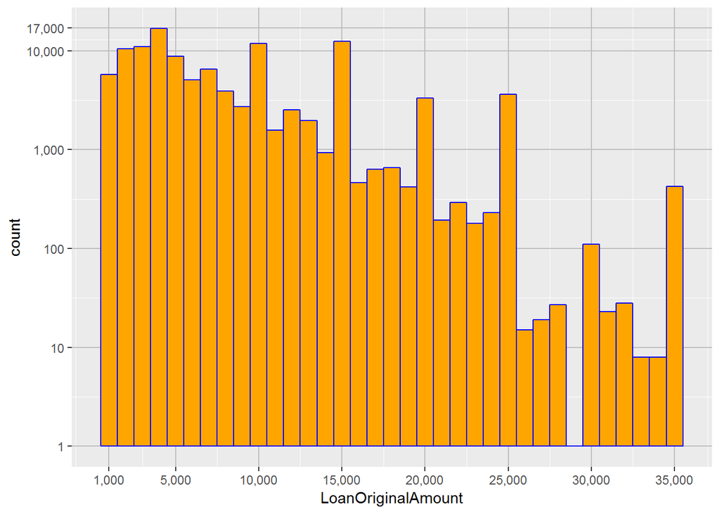

```
## LoanOriginalAmount:
##    Min. 1st Qu.  Median    Mean 3rd Qu.    Max.
##    1000    4000    6300    8315   12000   35000
```

> Terms appear to be 1, 3, or 5 years. Knowing this we can also examine loans by term:

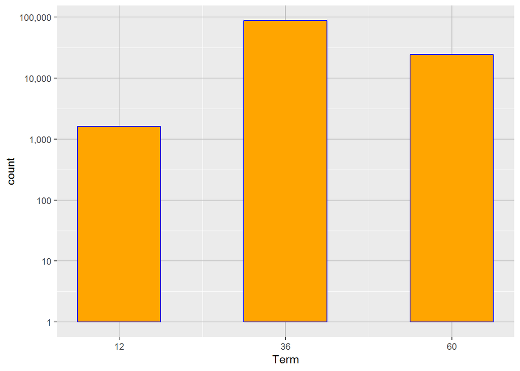

```
## Term:
##    Min. 1st Qu.  Median    Mean 3rd Qu.    Max.
##    12.0    36.0    36.0    40.8    36.0    60.0
```

```
## Loan Amounts by Term:
```

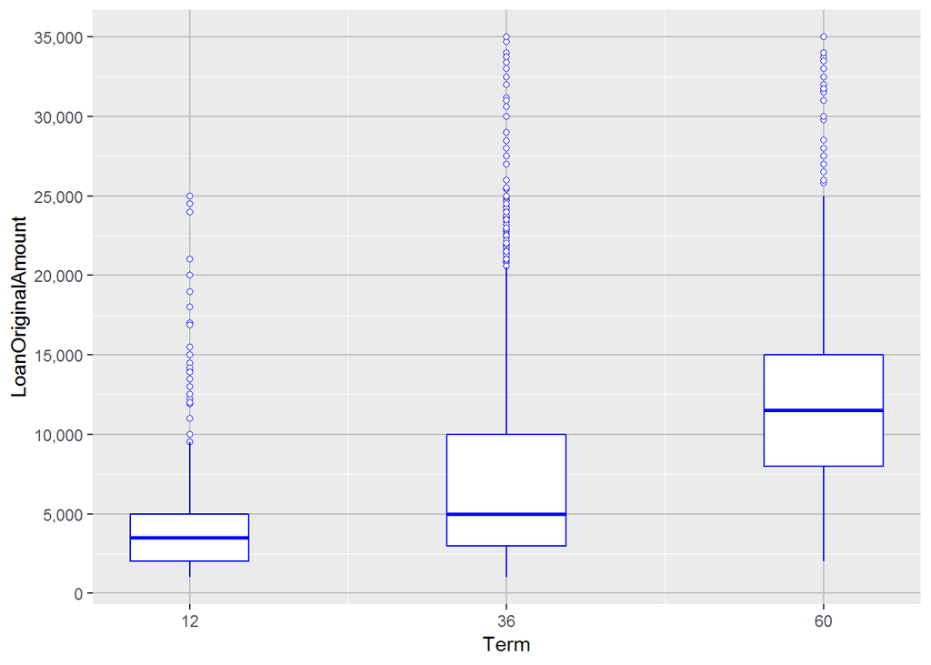

> Borrower APRs range from 0 to over 50% with the average around 21%

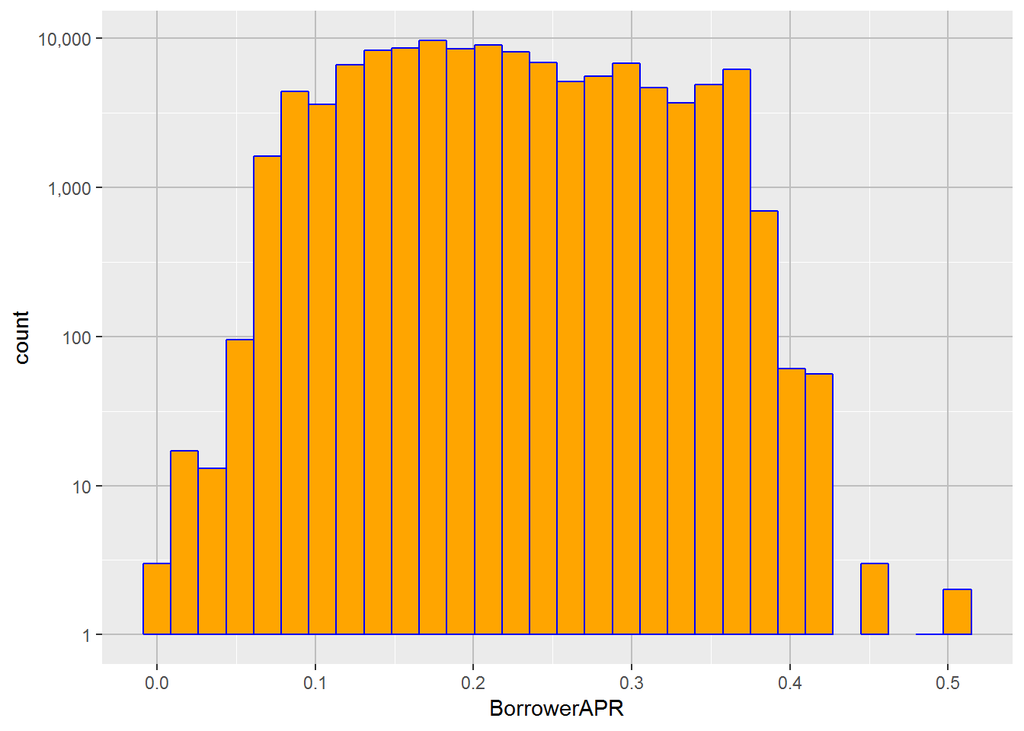

```
## BorrowerAPR:
##    Min. 1st Qu.  Median    Mean 3rd Qu.    Max.    NA's
## 0.00653 0.15629 0.20984 0.21898 0.28386 0.51229      25
```

> The loan data shows that around 10% of loans have been written off. Roughly half are current, and a third have been completed. Nearly 5% are in default, with the rest in final payment or late. This blog entry - [Understanding Loan Statuses](https://www.orchardplatform.com/blog/understanding-loan-statuses/) provides additional clarity on this terminology.

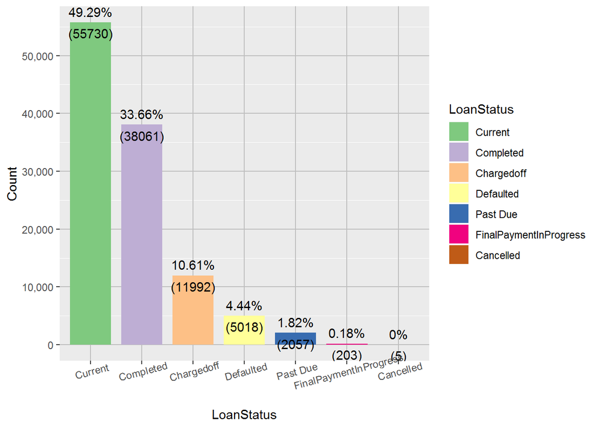

> How are the loans used? Examining the listing categories on a log scale we see the following:

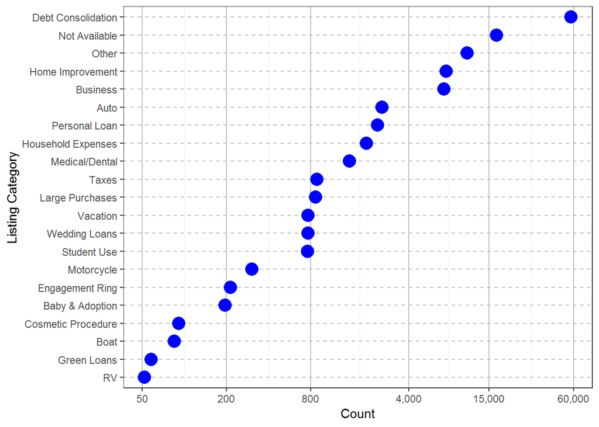

## Characteristics of Borrowers

> Incomes span a huge range, but the average is close to $5,000/month. If we segment that by employment status though, we can see that part-time and the unemployed groups are quite a bit below this average:

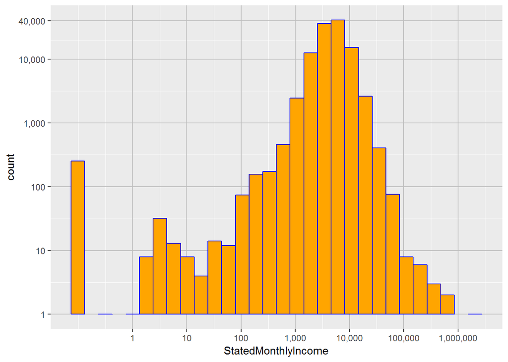

```
## IncomeVerifiable:
##    Mode   FALSE    TRUE
## logical    8587  104479
```

```
## StatedMonthlyIncome:
##    Min. 1st Qu.  Median    Mean 3rd Qu.    Max.
##       0    3199    4667    5605    6825 1750003
```

```
## Income by Employment Status:
```

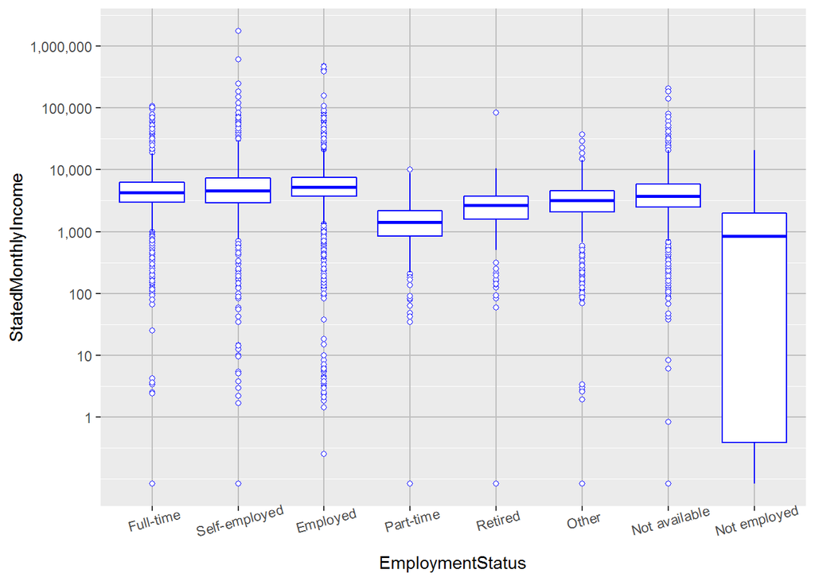

> Roughly half of the borrowers are home owners. The vast majority are employed with most of them being so for over 2 years. Again though, if we segment by employment status we see that part time workers quite a bit lower than the other groups. This makes intuitive sense. Interestingly, the “unemployed” group, while lower still has a positive number. So perhaps this represents past employment for them?

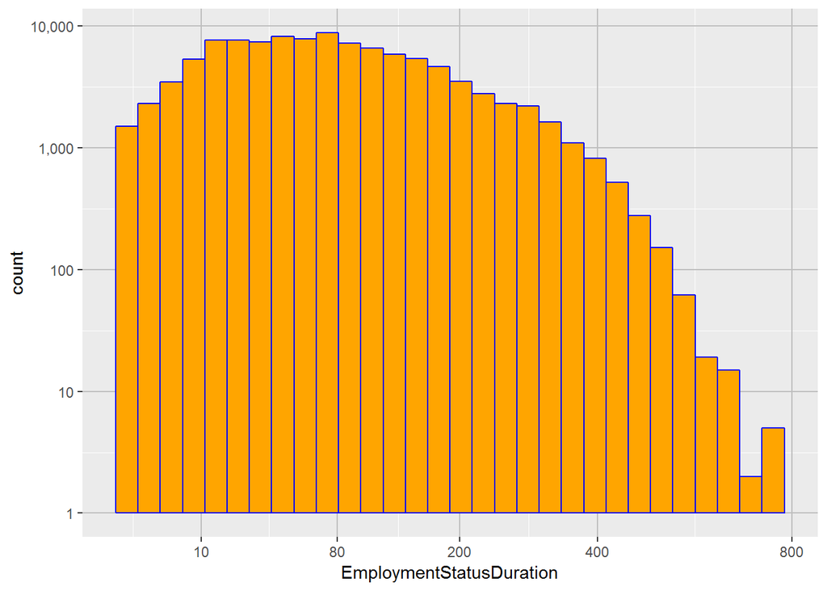

```
## IsBorrowerHomeowner:
##    Mode   FALSE    TRUE
## logical   56014   57052
```

```
## EmploymentStatus:
##     Full-time Self-employed      Employed     Part-time       Retired
##         26354          6052         66598          1088           795
##         Other Not available  Not employed
##          3742          7602           835
```

```
## EmploymentStatusDuration:
##    Min. 1st Qu.  Median    Mean 3rd Qu.    Max.    NA's
##    0.00   26.00   67.00   96.06  137.00  755.00    7625
```

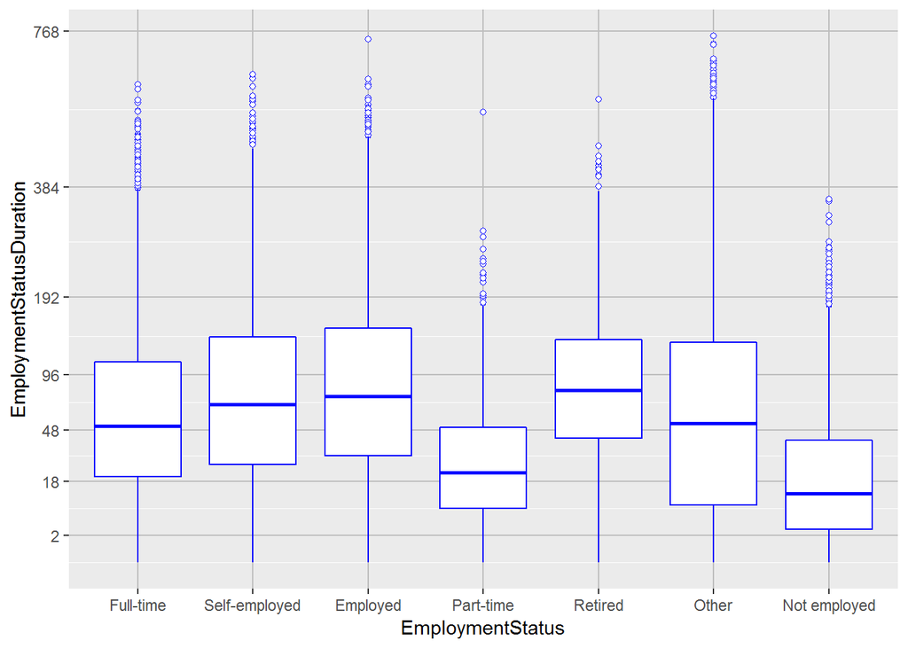

> Most borrowers are repaying at a rate of around $100 - $400/month though there are some outliers. Examing by employment status, we see that part-time, retired, and not available have a median repayment amount near the bottom of this range with many in their groups repayinging under $100/month:

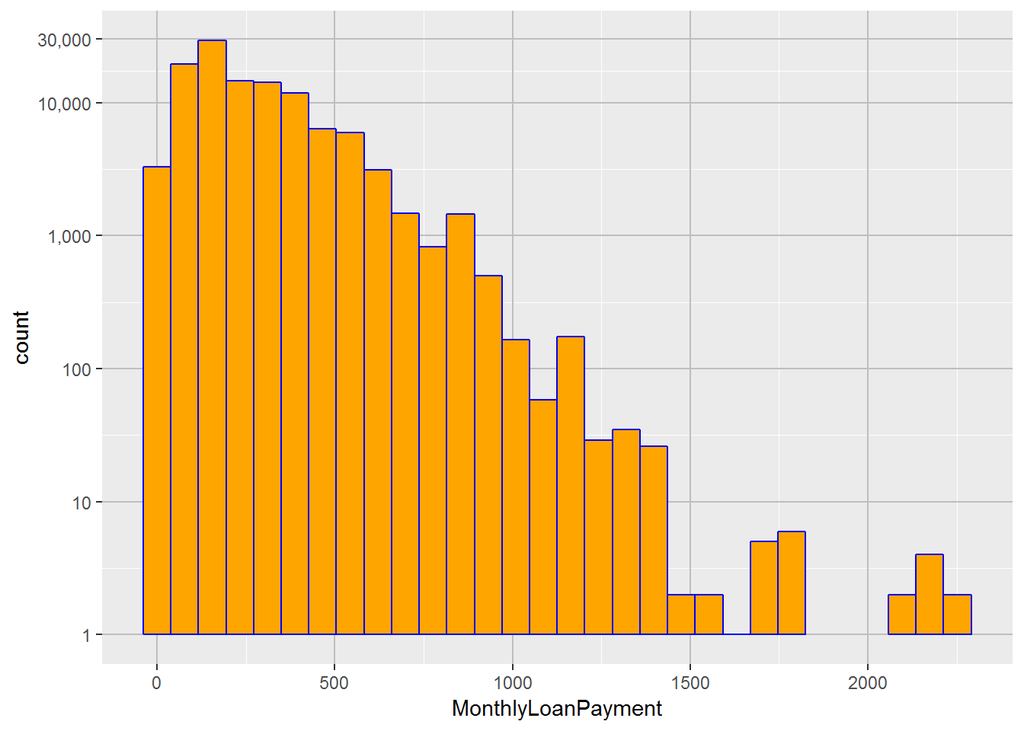

```
## MonthlyLoanPayment:
##    Min. 1st Qu.  Median    Mean 3rd Qu.    Max.
##     0.0   130.9   217.4   271.9   370.6  2251.5
```

```
## Loan Repayment by Employment Status:
```

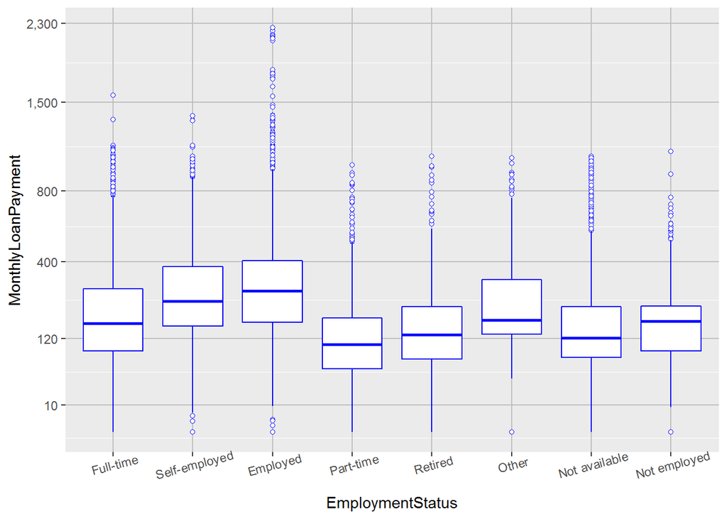

> Most borrowers have significant revolving credit balances, from $3,000 - $20,000 with some in excess of a million. Examing by employment status shows the part-time group has the lowest interquartile-range of revolving debt. The highest levels of debt seem to be limited to the full-time, self-employed, and employed groups:

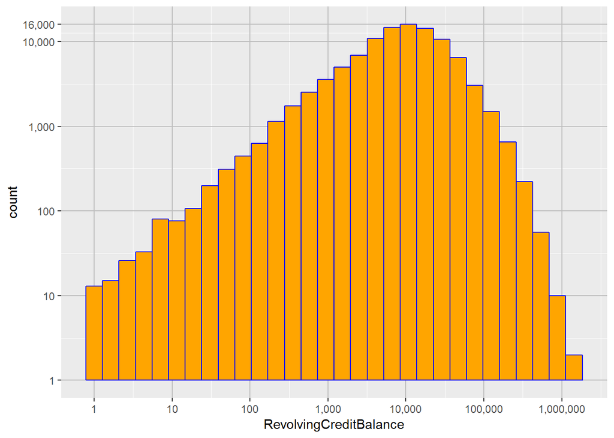

```
## RevolvingCreditBalance:
##    Min. 1st Qu.  Median    Mean 3rd Qu.    Max.    NA's
##       0    3099    8530   17592   19512 1435667    7604
```

```
## Revolving Credit Balance by Employment Status:
```

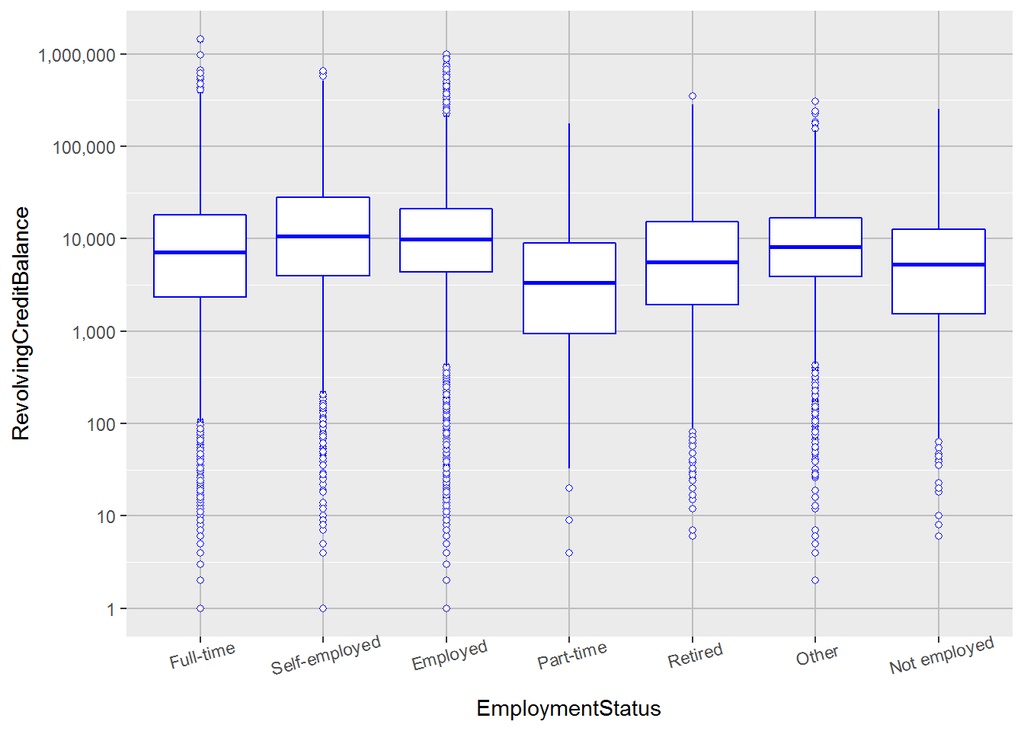

> Most borrowers appear to have a reasonable debt to income ratio, but there are some who owe more than they make. Per Wells Fargo, a ratio of .35 or less is good, .36 - .49 is marginal, and .5 or higher is problematic. The unemployed group also stands out for its fairly evenly distributed ratios all the way from good to truly awful:

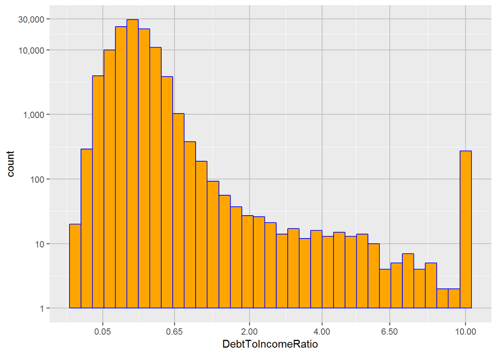

```
## DebtToIncomeRatio:
##    Min. 1st Qu.  Median    Mean 3rd Qu.    Max.    NA's
##   0.000   0.140   0.220   0.276   0.320  10.010    8472
```

```
## Debt-to-Income Ratio by Employment Status:
```

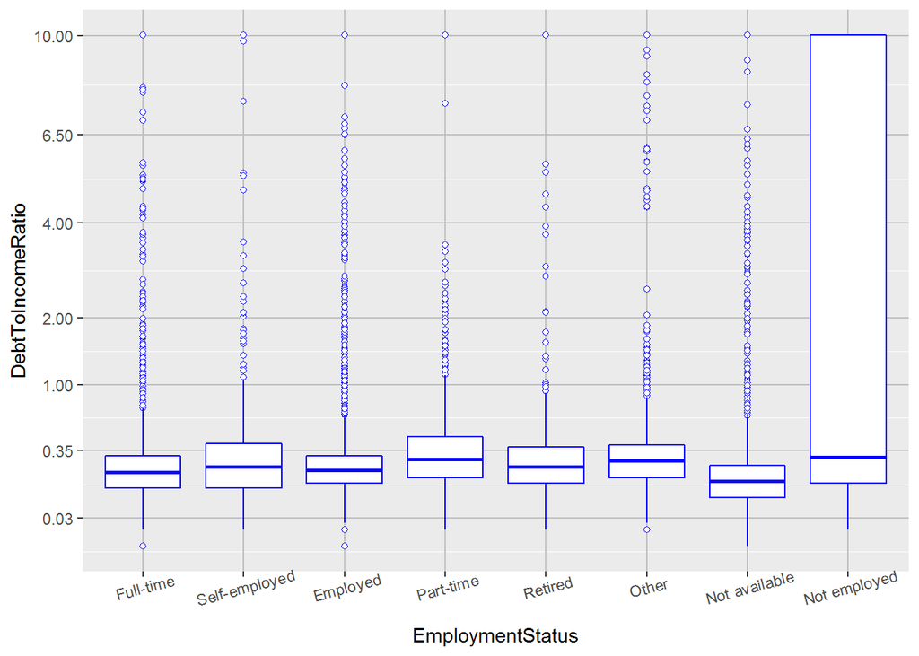

> Credit scores range from a little over 400 to a little under 900. We see the Not available group not only has the worst interquartile-range, but is also the only group with scores of 0. To put the scores in perspective, here’s how CreditSesame.com ranks them:

| Rating | Range |
| --- | --- |
| Excellent | 750 + |
| Good | 700 - 749 |
| Fair | 650 - 699 |
| Poor | 550 - 649 |
| Bad | 549 - |

Notes:

- For credit score there was an upper and lower range. To keep things simple  
  and conservative, only the lower range was selected.
- ProsperRating.alpha and CreditGrade are virtually the same - the reason they  
  are both included is that CreditGrade applies only to loans before 2009, and  
  ProsperRating.alpha applies to loans after July, 2009.

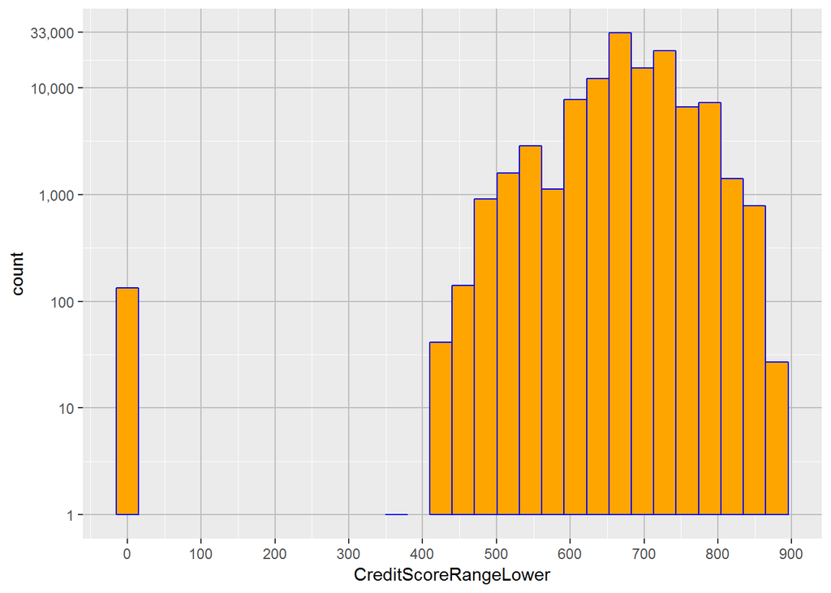

```
## CreditScoreRangeLower:
##    Min. 1st Qu.  Median    Mean 3rd Qu.    Max.    NA's
##     0.0   660.0   680.0   685.5   720.0   880.0     591
```

```
## CreditGrade:
##    AA     A     B     C     D     E    HR    NC  NA's
##  3509  3315  4389  5649  5153  3289  3508   141 84113
```

```
## ProsperRating.alpha:
##    AA     A     B     C     D     E    HR  NA's
##  5325 14390 15368 18096 14170  9716  6917 29084
```

```
## Credit Score by Employment Status:
```

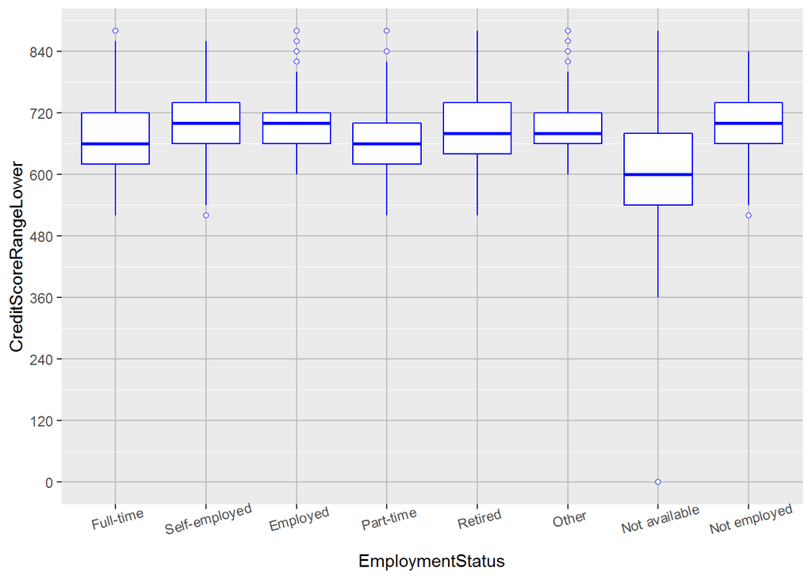

> The overwhelming majority of borrowers did not have friends that participated in their loans. The same is true for recommendations:

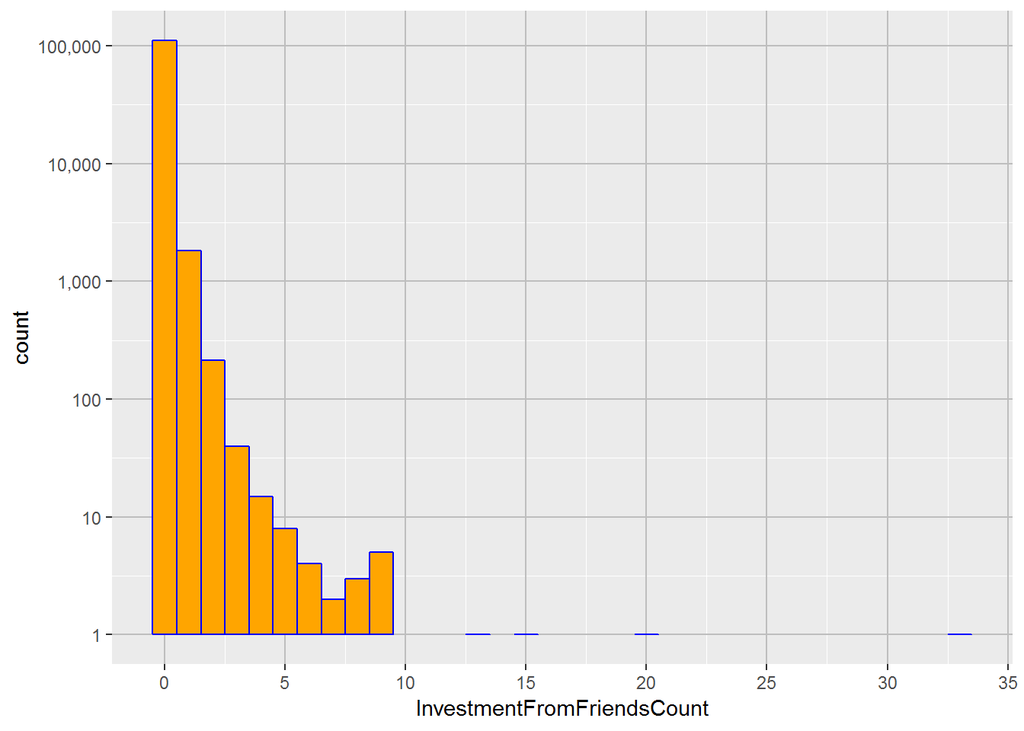

```
## InvestmentFromFriendsCount:
##     Min.  1st Qu.   Median     Mean  3rd Qu.     Max.
##  0.00000  0.00000  0.00000  0.02364  0.00000 33.00000
```

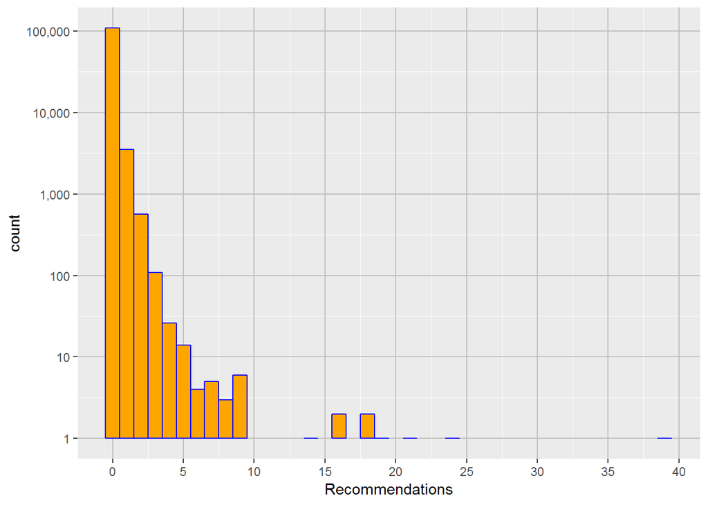

```
## Recommendations:
##     Min.  1st Qu.   Median     Mean  3rd Qu.     Max.
##  0.00000  0.00000  0.00000  0.04838  0.00000 39.00000
```

## Problematic Loans

> Most borrowers have no delinquencies. However, some have dozens or worse. Of note - the Not available group is significantly worse than the others:

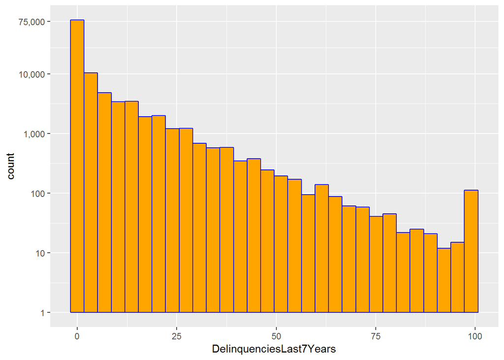

[output not shown]

[output not shown]

```
## DelinquenciesLast7Years:
##    Min. 1st Qu.  Median    Mean 3rd Qu.    Max.    NA's
##   0.000   0.000   0.000   4.159   3.000  99.000     990
```

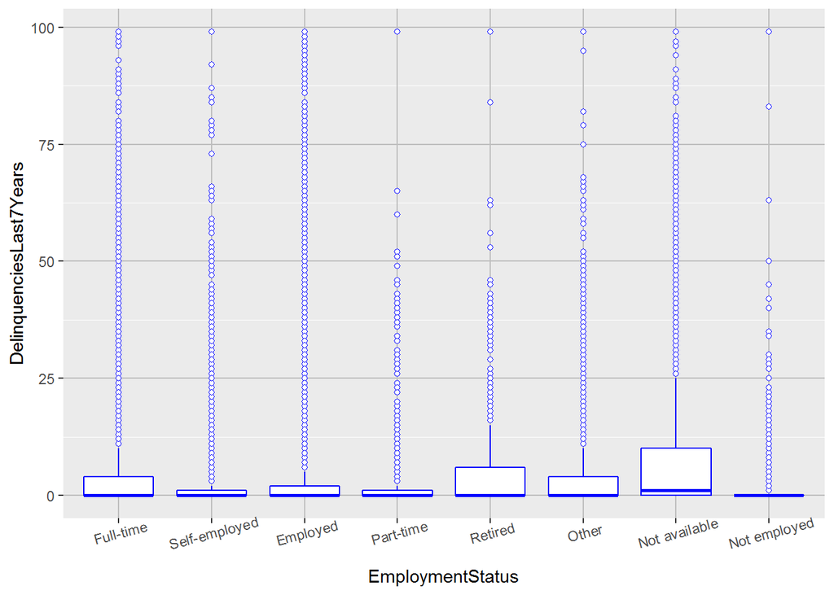

> For those with delinquencies, the amount ranges from small to nearly half a million. Breaking this down by employment status doesn’t seem to reveal additional insight:

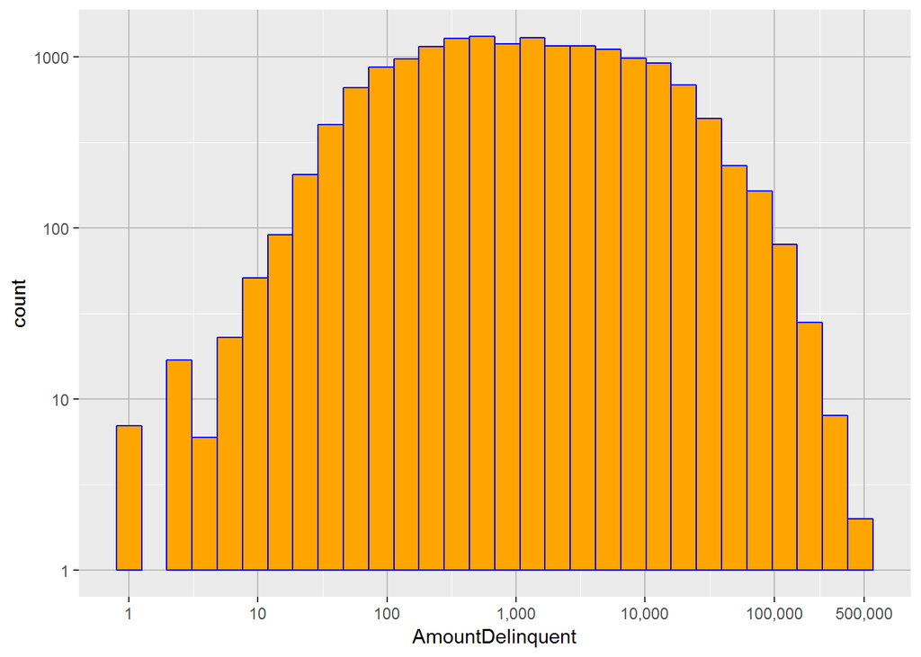

```
## AmountDelinquent:
```

```
##    Min. 1st Qu.  Median    Mean 3rd Qu.    Max.
##       1     247    1070    6331    5061  463881
```

```
## Amount Delinquent by Employment Status:
```

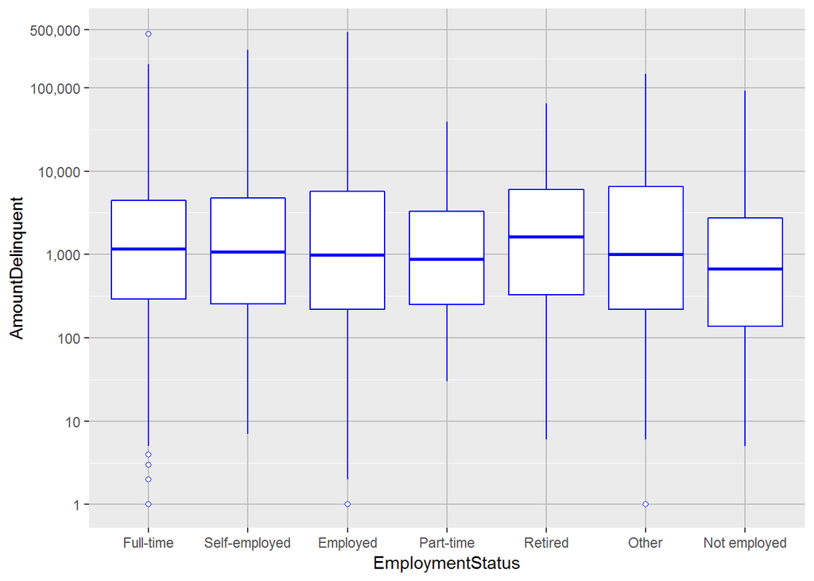

> Most borrowers have no public records on file (e.g., bankruptcies, tax liens, civil judgements). However, some have ten or more. Breaking this down by employment status, we see that Retired, Other, and Not Available are significantly worse than other groups:

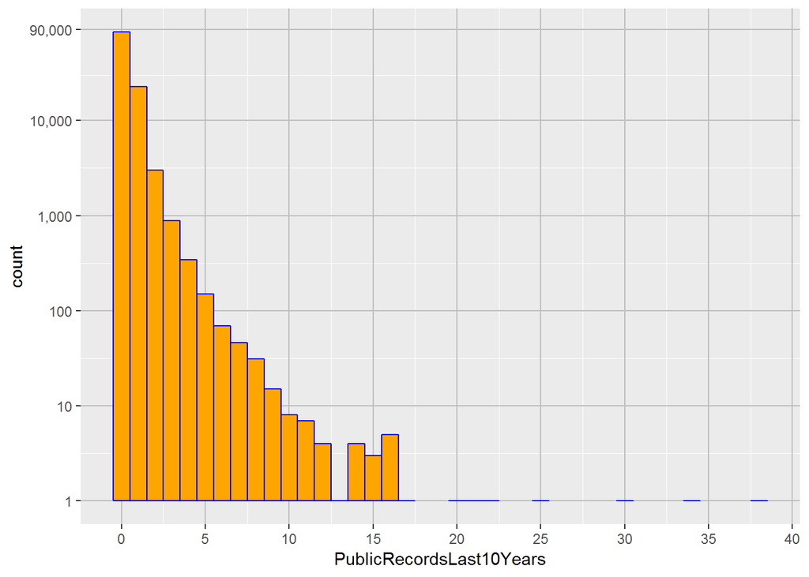

```
## PublicRecordsLast10Years:
##    Min. 1st Qu.  Median    Mean 3rd Qu.    Max.    NA's
##  0.0000  0.0000  0.0000  0.3128  0.0000 38.0000     697
```

```
## Public Records in Last 10 Years by Employment Status:
```

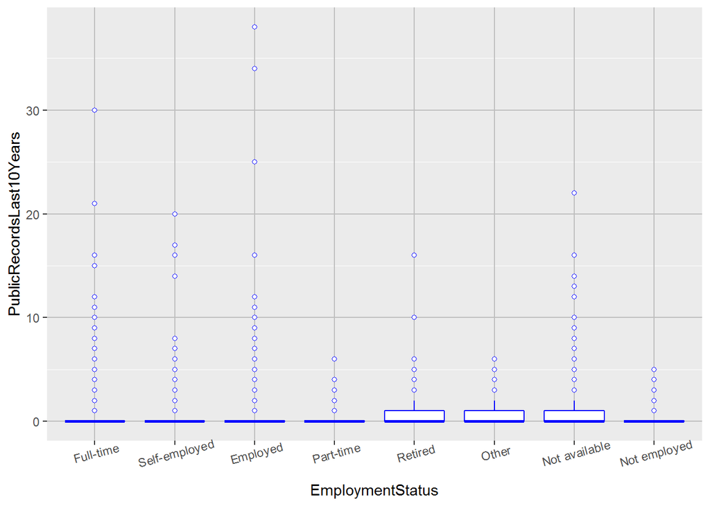

# Univariate Analysis

### What is the structure of your dataset?

> In the working data set, there are 113,066 loan records with 21 features.  
> With an average APR around 21%, these appear to be higher risk loans. As a point of reference, ValuePenguin.com says someone with excellent credit should be able to obtain a loan with an APR between 10.3 - 12.5%. The most popular listed loan category is debt consolidation, with unavailable and other coming in second and third respectively. Looking at the revolving credit balances, perhaps some of these loans are being used to consolidate credit card debt.

### What is/are the main feature(s) of interest in your dataset?

> There are some interesting factors with these peer-to-peer loans. Right off the bat, some risks jump out. Over 8,500 loans are made to someone whose income isn’t verifiable! We see that some borrowers have no income, and either aren’t employed or have an unknown employment status. Some borrowers have an outstanding revolving credit balance of over 1 million dollors! We see there are delinquent loans with amounts approaching half a million dollars. In addition, the worst case offender has 99 delinquent loans in the past 7 years. Some have dozens of public records and a low or non-existent credit score.

> There are many interesting facets to drill into. How is the borrower risk factored into the APR? Is it factored into the loan amount as well? In the various borrower grades (from Prosper), what percentage of them default or are late?

### What other features in the dataset do you think will help support your investigation into your feature(s) of interest?

> Borrower classification/risk, risk of default by group, impact of home ownership

### Did you create any new variables from existing variables in the dataset?

> No, with 81 original variables I had to initially work on reducing the number of features to a more manageable level.

### Of the features you investigated, were there any unusual distributions? Did you perform any operations on the data to tidy, adjust, or change the form of the data? If so, why did you do this?

> Most of the features have huge distributions and many require scale transformations such as log or square root. As documented above, I found duplicate observations within the data which I consolidated.

# Bivariate Plots Section

## Examining Correlated Features

```
## Potentially Interesting Correlations:
```

```
##   Correlation                 Axis1                      Axis2
## 1   0.3392832    LoanOriginalAmount                       Term
## 2  -0.3223227    LoanOriginalAmount                BorrowerAPR
## 3  -0.4292891 CreditScoreRangeLower                BorrowerAPR
## 4   0.3414884 CreditScoreRangeLower         LoanOriginalAmount
## 5   0.9318565    MonthlyLoanPayment         LoanOriginalAmount
## 6   0.7181096       Recommendations InvestmentFromFriendsCount
```

> For this plot, we see there is some (weak) correlation between the loan amount and the term. 12 month loans tend of be smaller. However, most smaller loans are for 36 months - we can see this term dominates. Furthermore, at the high end/upper half there doesn’t seem to be much difference between 36 and 60 month loans:

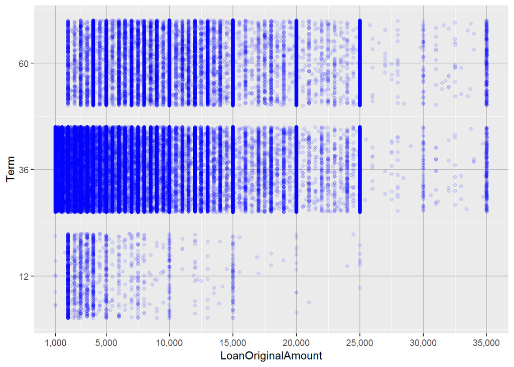

> Here we see a weak correlation between the loan amount and the APR charged. The highest APRs are for the smallest loans (under $5,000 - 6,000). Generally, as the amount increases, the APR tends to go down. If we use a linear model (orange line), there appears to be a decent correlation. However, if we use a non-linear model (red), we can see the correlation is much weaker:

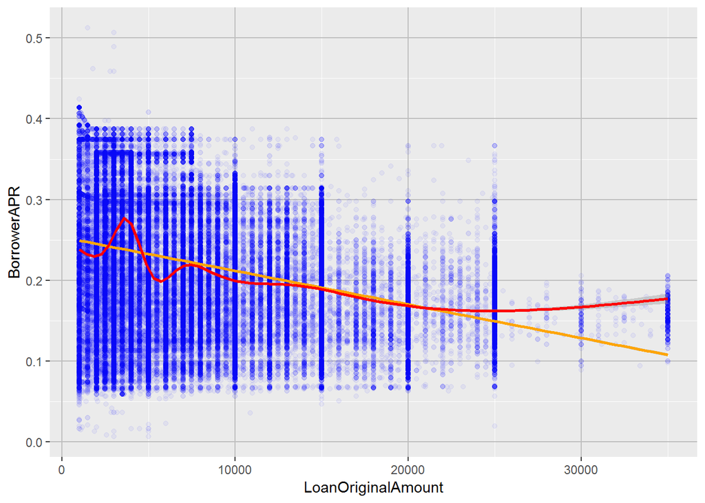

> Here there is clearly a relation between the borrower’s credit score and the APR charged. While it isn’t a strong relationship, you can see the trend of the APR generally decreasing as credit score increases. Using a linear model (orange), there appears to be a somewhat strong trend. However, using a non-linear model (red), we can see there is a relationship, but it’s a little murky:

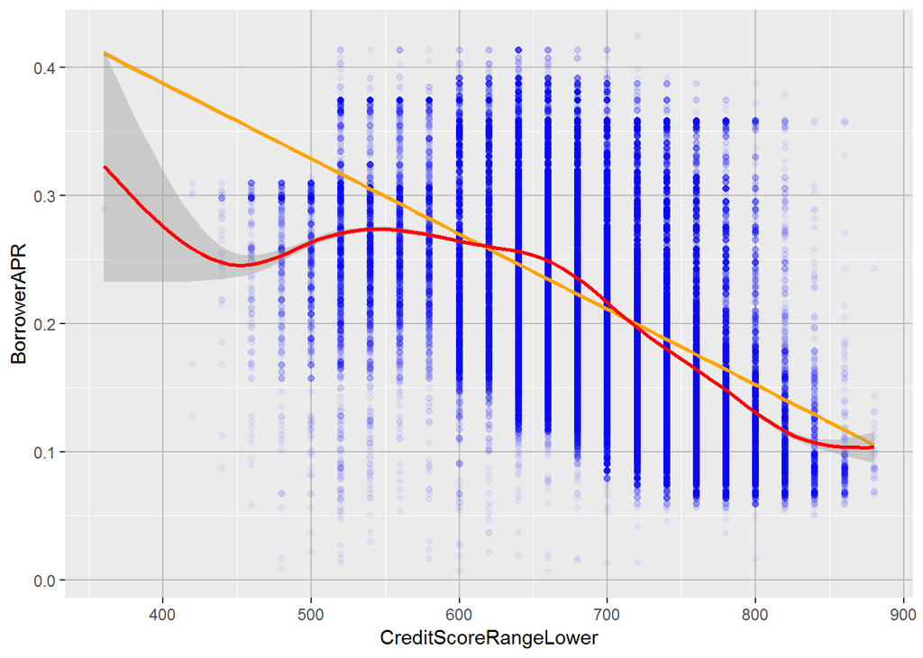

> Here we see a weak relationship between credit score and the loan amount. The lowest scores get small(er) loans and the highest loans are only given to those with higher scores. This makes sense in that with better credit a borrower is eligible for a larger loan. However, the borrower won’t necessarily choose to obtain a larger loan:

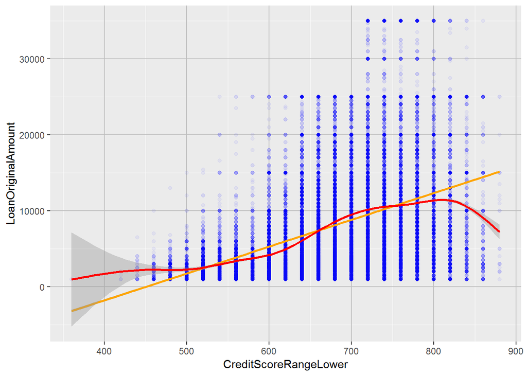

> For this plot we see a strong correlation, somewhat intuitively, between the loan amount and the monthly repayment of that loan. Note the three main areas: The first smaller group (line) that pays off there lot at a faster rate with higher monthly installments. This is the highest and steepest line. The second and majority group services their debt over a longer period with lower payments. Finally, the third and smallest group doesn’t repay the loan and most likely default. We see this group stay flat along the x-axis:

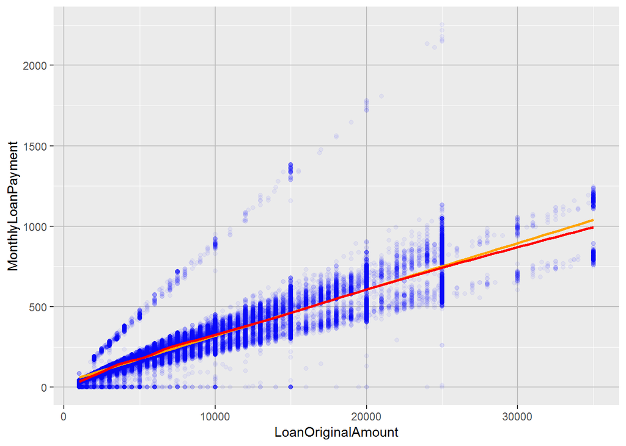

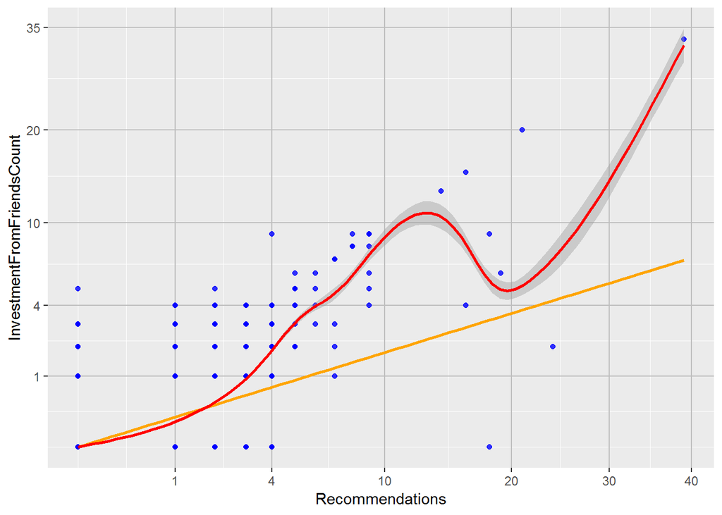